# Data block foundations

```python
# Uncomment line below when using Colab (this installs OpenCV4)
# %system SwiftCV/install/install_colab.sh
%install-location $cwd/swift-install
%install '.package(path: "$cwd/FastaiNotebook_07_batchnorm")' FastaiNotebook_07_batchnorm
%install '.package(path: "$cwd/SwiftCV")' SwiftCV
```

```
Installing packages:
	.package(path: "/home/ubuntu/fastai_docs/dev_swift/FastaiNotebook_07_batchnorm")
		FastaiNotebook_07_batchnorm
	.package(path: "/home/ubuntu/fastai_docs/dev_swift/SwiftCV")
		SwiftCV
With SwiftPM flags: []
Working in: /tmp/tmp9akl0jug/swift-install
Compile Swift Module 'jupyterInstalledPackages' (1 sources)
Initializing Swift...
Installation complete!
```

```python
//export
import Path
import TensorFlow
import Python
```

```python
import FastaiNotebook_07_batchnorm
```

```python
%include "EnableIPythonDisplay.swift"
IPythonDisplay.shell.enable_matplotlib("inline")
```

```
('inline', 'module://ipykernel.pylab.backend_inline')
```

## Image ItemList

### Download Imagenette

First things first, we need to download Imagenette and untar it. What follows is very close to what we did for MNIST.

```python
//export
public let dataPath = Path.home/".fastai"/"data"
```

```python
//export
public func downloadImagenette(path: Path = dataPath) -> Path {
    let url = "https://s3.amazonaws.com/fast-ai-imageclas/imagenette-160.tgz"
    let fname = "imagenette-160"
    let file = path/fname
    try! path.mkdir(.p)
    if !file.exists {
        downloadFile(url, dest:(path/"\(fname).tgz").string)
        _ = "/bin/tar".shell("-xzf", (path/"\(fname).tgz").string, "-C", path.string)
    }
    return file
}
```

```python
let path = downloadImagenette()
```

If we look at `path.ls()`, we see it returns a list of entries, which are structures with a `kind` and a `path` attribute. The `kind` is an enum that can be `file` or `directory`. `path` then points to the corresponding location.

```python
for e in path.ls() { print("\(e.path) (\(e.kind == .directory ? "directory": "file"))")}
```

```
/home/ubuntu/.fastai/data/imagenette-160/val (directory)
/home/ubuntu/.fastai/data/imagenette-160/train (directory)
/home/ubuntu/.fastai/data/imagenette-160/models (directory)
```

```python
for e in (path/"val").ls() { print("\(e.path) (\(e.kind == .directory ? "directory": "file"))")}
```

```
/home/ubuntu/.fastai/data/imagenette-160/val/n03888257 (directory)
/home/ubuntu/.fastai/data/imagenette-160/val/n03445777 (directory)
/home/ubuntu/.fastai/data/imagenette-160/val/n03425413 (directory)
/home/ubuntu/.fastai/data/imagenette-160/val/n01440764 (directory)
/home/ubuntu/.fastai/data/imagenette-160/val/n03028079 (directory)
/home/ubuntu/.fastai/data/imagenette-160/val/n02979186 (directory)
/home/ubuntu/.fastai/data/imagenette-160/val/n03394916 (directory)
/home/ubuntu/.fastai/data/imagenette-160/val/n02102040 (directory)
/home/ubuntu/.fastai/data/imagenette-160/val/n03417042 (directory)
/home/ubuntu/.fastai/data/imagenette-160/val/n03000684 (directory)
```

Let's have a look inside a class folder (the first class is tench):

```python
let pathTench = path/"val"/"n01440764"
```

```python
let imgFn = Path.home/".fastai/data/imagenette-160/val/n01440764/ILSVRC2012_val_00006697.JPEG"
imgFn.string
```

```
"/home/ubuntu/.fastai/data/imagenette-160/val/n01440764/ILSVRC2012_val_00006697.JPEG"
```

We will use opencv to read and resize our images.

```python
//export
import SwiftCV
import Foundation
```

```python
//load the image in memory
let imgContent = Data(contentsOf: imgFn.url)
// make opencv image
var cvImg = imdecode(imgContent)
// convert to RGB
cvImg = cvtColor(cvImg, nil, ColorConversionCode.COLOR_BGR2RGB)
```

By converting this image to a tensor then numpy, we can use `plt` to plot it:

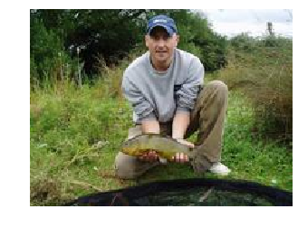

```
None
```

```python
let tensImg = Tensor<UInt8>(cvMat: cvImg)!
let numpyImg = tensImg.makeNumpyArray()
plt.imshow(numpyImg)
plt.axis("off")
plt.show()
```

### Grab all the images

Now that we have donloaded the data, we need to be able to recursively grab all the filenames in the imagenette folder. The following function walks recursively through the folder and adds the filenames that have the right extension.

```python
//export
public func fetchFiles(path: Path, recurse: Bool = false, extensions: [String]? = nil) -> [Path] {
    var res: [Path] = []
    for p in try! path.ls(){
        if p.kind == .directory && recurse {
            res += fetchFiles(path: p.path, recurse: recurse, extensions: extensions)
        } else if extensions == nil || extensions!.contains(p.path.extension.lowercased()) {
            res.append(p.path)
        }
    }
    return res
}
```

Note that we don't have a generic `open_image` function like in python here, but will be using a specific decode function (here for jpegs, but there is one for gifs or pngs). That's why we limit ourselves to jpeg exensions here.

```python
time { let fNames = fetchFiles(path: path, recurse: true, extensions: ["jpeg", "jpg"]) }
```

```
average: 1072.841281 ms,   min: 1072.841281 ms,   max: 1072.841281 ms
```

```python
let fNames = fetchFiles(path: path, recurse: true, extensions: ["jpeg", "jpg"])
```

```python
fNames.count == 13394
```

```
true
```

```python
print(type(of: cvImg))
```

```
Mat
```

## Prepare the data

```python
//export
public protocol ItemBase {
    func transform( _ tfms: [(inout Self) -> ()]) -> Self
}
```

```python
public struct Image: ItemBase{

    public var path: Path
    public lazy var img: Mat = {
        //print("Load image in memory")
        return imdecode(try! Data(contentsOf: path.url))
    } ()

    public init(_ img: Mat, _ path: Path) {
        (self.path,self.img) = (path,img)
    }

    public init(_ path: Path) { self.path = path }

    public mutating func show(){
        let tensImg = Tensor<UInt8>(cvMat: img)!
        let numpyImg = tensImg.makeNumpyArray()
        plt.imshow(numpyImg)
        plt.axis("off")
        plt.show()
    }

    public func transform(_ tfms: [(inout Image) -> ()]) -> Image{
        var tfmedImg = Image(path)
        tfms.forEach() { $0(&tfmedImg) }
        return tfmedImg
    }

    public mutating func toTensor() -> TF {
        return TF(Tensor<UInt8>(cvMat: img)!)
    }
}
```

```python
var img = Image(imgFn)
```

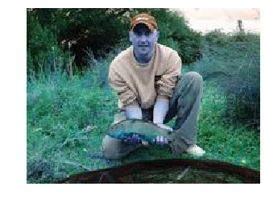

```python
img.show()
```

### ItemList

```python
// export
public struct ItemList<T> where T: ItemBase{
    public var items: [T]
    public let path: Path
    public var tfms: [(inout T) -> ()] = []

    public init(items: [T], path: Path, tfms: [(inout T) -> ()] = []){
        (self.items,self.path,self.tfms) = (items,path,tfms)
    }

    public init (_ il: ItemList<T>, newItems: [T]) {
        self.init(items: newItems, path: il.path, tfms: il.tfms)
    }

    public subscript(index: Int) -> T {
        return items[index].transform(tfms)
    }
}
```

```python
// export
public protocol InitableFromPath {
    init(_ path: Path)
}
extension Image: InitableFromPath {}
```

```python
// export
public extension ItemList where T: InitableFromPath {
    init(fromFolder path: Path, extensions: [String], recurse: Bool = true, tfms: [(inout T) -> ()] = []) {
        self.init(items: fetchFiles(path: path, recurse: recurse, extensions: extensions).map { T($0) },
                  path:  path,
                  tfms: tfms)
    }
}
```

```python
let il: ItemList<Image> = ItemList(fromFolder: path, extensions: ["jpeg", "jpg"])
```

[figure not shown]

```python
var img = il[0]
img.show()
```

```python
func convertRGB(_ img: inout Image) {
    img.img = cvtColor(img.img, nil, ColorConversionCode.COLOR_BGR2RGB)
}

func resize(_ img: inout Image, size: Int) {
    img.img = resize(img.img, nil, Size(size, size), 0, 0, InterpolationFlag.INTER_AREA)
}
```

```python
let il: ItemList<Image> = ItemList(fromFolder: path, extensions: ["jpeg", "jpg"],
                                  tfms: [convertRGB, { resize(&$0, size:128) }])
```

[figure not shown]

```python
var img = il[0]
img.show()
```

### Split

```python
// export
public struct SplitData<T> where T: ItemBase{
    public let train, valid: ItemList<T>
    public var path: Path { return train.path }

    public init(train: ItemList<T>, valid: ItemList<T>){
        (self.train, self.valid) = (train, valid)
    }

    public init(_ il: ItemList<T>, fromFunc: (T) -> Bool){
        self.init(train: ItemList(il, newItems: il.items.filter { !fromFunc($0) }),
                  valid: ItemList(il, newItems: il.items.filter {  fromFunc($0) }))
    }
}
```

```python
// export
public func grandParentSplitter(fName: Path, valid: String = "valid") -> Bool{
    return fName.parent.parent.basename() == valid
}
```

```python
let sd = SplitData(il) { grandParentSplitter(fName: $0.path, valid: "val") }
```

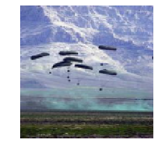

```python
var img = sd.train[0]
img.show()
```

### Processor

```python
// export
public protocol Processor {
    associatedtype Input: ItemBase
    associatedtype Output: ItemBase

    mutating func initState(_ items: [Input])
    func process1(_ item: Input) -> Output
    func deprocess1(_ item: Output) -> Input
}
```

```python
// export
public extension Processor {
    func process(_ items: [Input]) -> [Output] {
        return items.map { process1($0) }
    }

    func deprocess(_ items: [Output]) -> [Input] {
        return items.map { deprocess1($0) }
    }
}
```

```python
// export
public struct NoopProcessor<Item>: Processor where Item: ItemBase{
    public init() {}

    public mutating func initState(_ items: [Item]) {}

    public func process1  (_ item: Item) -> Item { return item }
    public func deprocess1(_ item: Item) -> Item { return item }
}
```

```python
//export
extension String: ItemBase {
    public func transform(_ tfms: [(inout String) -> ()]) -> (String) { return self }
}

extension Int: ItemBase {
    public func transform(_ tfms: [(inout Int) -> ()]) -> (Int) { return self }
}
```

```python
// export
public struct CategoryProcessor: Processor {
    public init() {}
    public var vocab: [String]? = nil
    public var reverseMap: [String: Int]? = nil

    public mutating func initState(_ items: [String]) {
        vocab = Array(Set(items)).sorted()
        reverseMap = [:]
        for (i,x) in vocab!.enumerated() { reverseMap![x] = i }
    }

    public func process1  (_ item: String) -> Int { return reverseMap![item]! }
    public func deprocess1(_ item: Int) -> String { return vocab![item] }
}
```

### Label

When we build the datasets, we don't need to return a tupe (item, label) but to have the tensor(s) with the items and the tensor(s) with the labels separately.

```python
public struct LabeledItemList<I, L> where I:ItemBase, L: ItemBase{
    public var inputs: ItemList<I>
    public var labels: ItemList<L>
    public var path: Path { return inputs.path }

    public init(inputs: ItemList<I>, labels: ItemList<L>) {
        (self.inputs,self.labels) = (inputs,labels)
    }

    public subscript(_ i: Int) -> (I, L) {
        return (inputs[i], labels[i])
    }
}

public extension LabeledItemList {
    init(_ il: ItemList<I>, labelWithFunc f: @escaping (I) -> L) {
        self.init(inputs: il, labels: ItemList(items: il.items.map{ f($0) }, path: il.path, tfms: []))
    }
}
```

```python
public func parentLabeler(_ fName: Path) -> String { return fName.parent.basename() }
```

```python
let ll = LabeledItemList(il, labelWithFunc: { parentLabeler($0.path) })
```

[figure not shown]

```
n03888257
```

```python
var x = ll[0]
x.0.show()
print(x.1)
```

```python
public func process<PI> (_ il: ItemList<PI.Input>, proc: PI) -> ItemList<PI.Output> where PI: Processor {
    return ItemList(items: proc.process(il.items), path: il.path, tfms: [])
}
```

```python
public func process<PI, PL> (_ lil: LabeledItemList<PI.Input, PL.Input>, procInp: PI, procLab: PL)
-> LabeledItemList<PI.Output, PL.Output> where PI: Processor, PL: Processor {
    return LabeledItemList(
        inputs: process(lil.inputs, proc: procInp),
        labels: process(lil.labels, proc: procLab)
    )
}
```

```python
public struct SplitLabeledData<PI, PL> where PI: Processor, PL: Processor{
    public var train, valid: LabeledItemList<PI.Output, PL.Output>
    public var path: Path { return train.path }
    public var procInp: PI
    public var procLab: PL

    public init(_ rawTrain: LabeledItemList<PI.Input,PL.Input>,
                _ rawValid: LabeledItemList<PI.Input,PL.Input>,
                procInp: inout PI,
                procLab: inout PL) {
        procInp.initState(rawTrain.inputs.items)
        procLab.initState(rawTrain.labels.items)
        train = process(rawTrain, procInp: procInp, procLab: procLab)
        valid = process(rawValid, procInp: procInp, procLab: procLab)
        (self.procInp,self.procLab) = (procInp,procLab)
    }
}
```

```python
public extension SplitLabeledData {
    init(_ sd: SplitData<PI.Input>,
         labelWithFunc f: @escaping (PI.Input) -> PL.Input,
         procInp: inout PI,
         procLab: inout PL) {
        self.init(LabeledItemList(sd.train, labelWithFunc: f),
                  LabeledItemList(sd.valid, labelWithFunc: f),
                  procInp: &procInp,
                  procLab: &procLab)
    }
}
```

```python
var procInp = NoopProcessor<Image>()
var procLab = CategoryProcessor()
```

```python
var sld = SplitLabeledData(sd, labelWithFunc: { parentLabeler($0.path) }, procInp: &procInp, procLab: &procLab)
```

Labeling loses the transforms.

```
n03888257
```

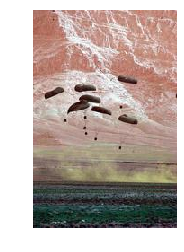

```python
var x = sld.train[0]
x.0.show()
print(sld.procLab.deprocess1(x.1))
```

So we add them back

```python
sld.train.inputs.tfms = [convertRGB, { resize(&$0, size:128) }]
```

```
n03888257
```

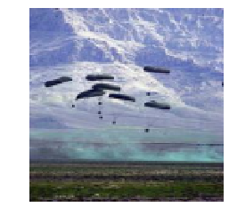

```python
var x = sld.train[0]
x.0.show()
print(sld.procLab.deprocess1(x.1))
```

```python
public extension SplitLabeledData{
    mutating func transform(_ tfms: ([(inout PI.Output) -> ()], [(inout PI.Output) -> ()])){
        train.inputs.tfms = tfms.0
        valid.inputs.tfms = tfms.1
    }
}
```

```python
var sld = SplitLabeledData(sd, labelWithFunc: { parentLabeler($0.path) }, procInp: &procInp, procLab: &procLab)
let tfms = [convertRGB, { resize(&$0, size:512) }]
sld.transform((tfms, tfms))
```

```
n03888257
```

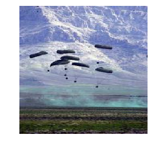

```python
var x = sld.train[0]
x.0.show()
print(sld.procLab.deprocess1(x.1))
```

What's below doesn't work with that's above.

```python
func loadSync(_ n: Int) -> TF {
    var imgs: [TF] = []
    for i in 1...n {
        var img = sld.train[i].0
        imgs.append(img.toTensor().expandingShape(at: 0) / 255.0)
    }
    return TF(concatenating: imgs, alongAxis: 0)
}
```

```python
time { let imgs = loadSync(100) }
```

```
average: 525.443178 ms,   min: 525.443178 ms,   max: 525.443178 ms
```

```python
func loadQSync(_ n: Int) -> [Image] {
    var imgs: [Image] = []
    let queue = DispatchQueue(label: "myqueue")
    queue.sync {
        for i in 1...n { imgs.append(sld.train[i].0) }
    }
    return imgs
}
```

```python
time { let imgs = loadQSync(100) }
```

```
average: 156.429778 ms,   min: 156.429778 ms,   max: 156.429778 ms
```

```python
func loadAsync(_ n: Int) -> [Image] {
    var imgs: [Image] = []
    let group = DispatchGroup()
    group.enter()
    let queue = DispatchQueue(label: "myqueue")
    queue.async {
        for i in 1...n { imgs.append(sld.train[i].0) }
        group.leave()
    }
    group.wait()
    return imgs
}
```

```python
time { let imgs = loadAsync(100) }
```

```
average: 161.545611 ms,   min: 161.545611 ms,   max: 161.545611 ms
```